# Mississippi

4,600

30%

5

People In Prison Past  
Parole Eligibility*

Prison Population Incarcerated  
Past Parole Eligibility

Parole Board  
Members<sup>1</sup>

*Projection based on 2023 prison population. This and other figures regarding people past parole eligibility include people in prison with sentences of more than one year who have not already been released on parole and excludes people with life sentences.

**Parole Eligibility**

## How Parole Eligibility Is Determined

Parole eligibility refers to the point in a person’s prison sentence when they become eligible for consideration for release under parole. Often, there is a minimum term a person must serve before becoming parole eligible. Parole is a conditional release, allowing the person to serve the remainder of their sentence in the community under supervision, rather than in prison.

In Mississippi, for people in prison convicted of nonviolent crimes, parole-release eligibility generally occurs at the 25-percent mark of their judicial maximum terms or at 10 years, whichever is less. For most people in prison convicted of violent offenses, parole-release eligibility comes at the 50-percent milestone of their maximum terms or at 20 years, whichever is less.²

## In Prison Past Parole Eligibility

Most recent data shows that 34 percent of people in prison were eligible for parole and incarcerated past parole eligibility at the end of the year, another 25 percent will reach parole eligibility next year, and an additional 41 percent will reach parole eligibility in more than one year.

[interactive chart not shown]

From 2010 to 2020, the percent of people in prison past parole eligibility increased by 25 percent. Our projection model estimated that the percent of people past their initial parole eligibility decreased by 24 percent from 2020 to 2023.

[interactive chart not shown]

## Demographics

**Race and Ethnicity**

65 percent of people in prison past parole eligibility were Black, non-Hispanic.

[interactive chart not shown]

**Sex**

95 percent of people in prison past parole eligibility were male.

[interactive chart not shown]

**Age**

31 percent of people in prison past parole eligibility were between the ages of 35 and 44 years old.

[interactive chart not shown]

## Offense Types

55 percent of people in prison past parole eligibility were in prison for violent offenses and 45 percent for nonviolent offenses. The most common offense types among people in prison past parole eligibility were property offenses (22 percent) and rape or sexual assault offenses (22 percent).

[interactive chart not shown]

## Sentence Lengths

45 percent of people in prison past parole eligibility had sentence lengths between 10 and 24.9 years.

[interactive chart not shown]

## Key Terms and Data Sources

### Key Terms

- **Parole Eligibility Year (PEY):** The first year in which a person is eligible for discretionary parole, determined by state-specific sentencing practices. PEY reflects the point at which a person who is incarcerated can be considered for release, though it does not guarantee release. If a parole board has discretion to set that date, PEY is the first year that the board can set a hearing.
- **Parole-Eligible Individual:** A person who is serving a sentence for a criminal offense who remains incarcerated past their PEY. This excludes individuals who were returned to prison from parole and people with life sentences or sentences of less than one year.
- **Projections:** Statistical models used to estimate future values based on historical trends. Here, projections estimate the number of people incarcerated past their parole eligibility date in 2023, based on trends from 2010 to 2020.
- **Racial Disparities:** Racial disparities refer to measurable differences in outcomes, access, or treatment between racial or ethnic groups. Racial disparities have many causes and are manifested in statistics like arrest rates, sentencing lengths, and prison populations. Racial disparities should not be confused with individual acts of racism or prejudice. While individual bias can contribute to disparities, these patterns exist at a systemic level across institutions.
- **Relative Rate Index (RRI):** A comparative measure that evaluates the rate of an outcome (such as incarceration or remaining in prison past parole eligibility) between two groups. For this project, RRI compares the rates for Black and Hispanic populations to those of the White population.

### Data Sources

- **Parole Eligibility:** For parole-related metrics, including the year that an individual becomes eligible for parole, data from the [National Corrections Reporting Program (NCRP) Selected Variables](https://www.icpsr.umich.edu/web/NACJD/series/38) was the primary source. NCRP collects individual-level data on prison admissions, releases, custody populations, and parole status changes. The data includes demographics, offenses, sentences, admission/release types, and time served from individual records, with collection ongoing since 1983. At least 47 states contributed data during the time period of our study, but this data varied in quality and, as a result, not all states are included in our analyses. While the most recent NCRP data extends only to 2020, projections for 2023 were made to provide up-to-date estimates.
- **Prison Populations, prior to 2023:** The number of people who are incarcerated by race, ethnicity, and sex was derived from the [Bureau of Justice Statistics (BJS) Prisoners Series](https://bjs.ojp.gov/library/publications/prisoners-2022-statistical-tables) and the [National Prisoner Statistics (NPS)](https://bjs.ojp.gov/data-collection/national-prisoner-statistics-nps). These datasets are collected annually from all 50 states and provide detailed aggregate information on prison populations for each state, including data on race and sex of people who are incarcerated. The most recent data available at the time of our analysis was for 2022.
- **Prison Populations, 2023:** Our modelling approach required more recent prison population numbers than were available from the NPS, so we manually collected prison population data from state departments of corrections for 2023.<sup>3</sup>

## Estimation Methodology

We began by limiting our population to individuals incarcerated in prison, excluding people who were returned to prison from parole and those serving a life sentence or a sentence of less than one year. Parole eligibility year (PEY) estimates for 2020 and earlier were calculated in three steps. (1) We started with the PEY variable in the NCRP for the state and year of interest. (2) Next, we looked at the PEY provided in previous years’ reports to identify the earliest PEY recorded for a person. This can help capture PEY that is missing for people who should have one and likely had their PEY deleted or replaced with a new date after a failed hearing. (3) When PEY was missing, we used the state’s parole eligibility rules to create a conservative estimate of the PEY. We also replaced the reported PEY if our rules-based estimate was earlier than the PEY reported in the NCRP data. Because the estimate is conservative, the results may undercount the number of people in prison past their PEY.  
To match people to their PEY in in previous years’ reports without an NCRP identifier available across reports, we create our own identifier based on the variables that should be constant across reports: state, sex, race, admission year, admission type, age at time of admission, sentence length, max. release year, offense (detailed), and offense (general) terms count, sentences count, most serious prior sentence, last serious prior offense, and second to last serious prior offense. If in any year multiple people had the same identifier, the latest PEY among them was selected, with missing PEY treated as later than any other year. If a previous report returns a PEY earlier than the one from the year of interest, that one was selected. The process was repeated for each report back until 2000.  
Rules-based imputation is based on rules identified by Reitz and colleagues and the state’s code.⁴ It is a conservative estimate computed as follows: First, each person was assigned a minimum sentence based on the corresponding percentage of the maximum sentence (25 percent for those whose most serious offense was nonviolent and 50 percent for those whose most serious offense was violent). Second, the absolute minimum sentence of 10 years for those whose most serious offense was nonviolent and 20 years for those whose most serious offense was violent was computed. The previously computed rules-based estimate was replaced by the absolute minimum sentence if the latter was shorter. Third, in Mississippi people convicted three times are generally ineligible for parole. Therefore, when the data allowed identifying previous offenses, no PEY was imputed for people with three or more offenses unless they already had a PEY on record. When the data did not allow seeing previous sentences, no PEY was imputed for people who did not already have one on record. All fractions were rounded up. If the rules-based imputation was earlier than the one found in the previous steps, it was used as the best estimate.  
Results were then checked against available data from the states about people past parole eligibility and parole hearing approval rates. We also checked whether estimates and the percent missing PEY were consistent with the state’s eligibility rules and for the potential influence of any missing data in the imputation. Data was excluded for any year when more than 33 percent of the cases were missing the admission year or the maximum sentence length variables, as well as for years when more than 40 percent of the relevant cases were missing PEY after imputation.⁵ No year had to be excluded for this reason for Mississippi. Even if missing data was under this threshold, if the missingness appeared to follow a pattern that might bias the estimate, that year’s data was excluded for the state. This was evident, for instance, when the percent of people past PEY substantially dropped as a state stopped recording a variable for newly admitted people. If due to missingness there is reason to believe there is likely an undercount of people past PEY of a few percentage points, but it is not certainly a major undercount, this is noted at the top. This is the case, for instance, when the state’s rules make rules-based imputation too conservative for some people and many people were still missing a PEY after looking at previous records. Conversely, if a state was missing more than the abovementioned thresholds any year but due to other available data that missingness was not problematic, the year was not excluded. No year had to be excluded for this reason for Mississippi.  
Because there was a change in the trend of percentage of people past PEY in 2020 in many states, likely due to the COVID-19 pandemic, figures that report data from one year are from 2019, the latest year with reliable estimates available for Mississippi.  
Our models were restricted to a subgroup of the prison population, excluding all individuals who were returned to prison from parole and people with life sentences or sentences of less than one year. Estimates for the percentage of people who had passed their PEY in 2023 were derived from a regression model based on data from 2010 to 2020. This regression accounted for state-specific trends in the annual changes to the percentage of people past their PEY over the decade, as well as the impact of special COVID-19 policies in 2020. (Technically, a mixed-effects model with random slopes for both factors was used.) The total number of people past their PEY in 2023 was calculated by multiplying the 2023 restricted subgroup of the population by the estimated percentage of people past their PEY.  
The size of the restricted subgroup of the population in 2023 was estimated using a regression model based on the percentage of the total custody population represented by this subgroup between 2010 and 2020. For data from 2010 to 2022, the custody population reported in the National Prisoner Statistics (NPS) was used.

## Endnotes

¹ Alexis Lee Watts, Julie Matucheski, Noah Finn, and Kevin R. Reitz, *Profiles in Parole* Release and Revocation: Examining the Legal Framework in the United States – Mississippi (Robina Institute of Criminal Law and Criminal Justice, 2019), https://robinainstitute.umn.edu/sites/robinainstitute.umn.edu/files/2022-02/mississippi_parole_profile.pdf, 11.  
² Kevin R. Reitz, Bree Crye, and Edward E. Rhine, *Prison-Release Discretion and Prison Population Size: State Report: Mississippi* (Robina Institute of Criminal Law and Criminal Justice, June 2022), https://robinainstitute.umn.edu/sites/robinainstitute.umn.edu/files/2023-03/mississippi_doi_report_6_20_22.pdf, 8-10.  
³ Mississippi Department of Corrections, *Fact Sheet as of January 1, 2024* (Jackson, MS: Mississippi Department of Corrections, 2024), accessed October 1, 2024, https://www.mdoc.ms.gov/sites/default/files/Monthly_Fact_Sheets/2024_Monthly%20Fact%20Sheet_January.pdf, 1.  
⁴ Kevin Reitz et al., *American Prison-Release Systems: Indeterminacy in Sentencing and the Control of Prison Population Size*, Final Report (Minneapolis, Minnesota: Robina Institute, University of Minnesota, 2022), accessed October 1, 2024, https://robinainstitute.umn.edu/sites/robinainstitute.umn.edu/files/2022-05/american_prison-release_systems.pdf, 36-43; Reitz, Crye, Rhine, *Prison-Release Discretion*, 8-10; MS Code § 99-19-81 (2020).  
⁵ NCRP provides three datasets for each year: “year-end population,” “releases,” and “terms.” The latter includes both each year’s year-end population and releases, along with data on previous incarceration terms for each person. In addition to having more data, it is not always completely consistent with the data in the other two datasets, with some cases or variables missing some years. Because of this, the analysis on the year-end population and the releases population was replicated with the “terms” dataset. When the “terms” dataset identified a higher proportion of the relevant population as being past their PEY in a given year and state—that is, the “terms” estimate was less conservative—that dataset was selected—except in rare cases where that higher proportion was an artifact of missing data in the “terms” dataset.

**Prison Population**

## Prison Population Trends

From 2010 to 2022, the prison population decreased 18 percent, changing from 21,067 in 2010 to 17,332 in 2022.

[interactive chart not shown]

## Demographics

**Race and Ethnicity**

59 percent of people in prison were Black, non-Hispanic.

[interactive chart not shown]

**Sex**

92 percent of people in prison were male.

[interactive chart not shown]

**Age**

33 percent of people in prison were between the ages of 25 and 34 years old.

[interactive chart not shown]

## Offense Types

54 percent of people in prison were in prison for violent offenses and 46 percent for nonviolent offenses. The most common offense type among people in prison were property offenses (20 percent).

[interactive chart not shown]

## Sentence Lengths

39 percent of people in prison had sentence lengths between 10 and 24.9 years.

[interactive chart not shown]

**Prison Releases**

## Prison Release Trends

From 2010 to 2020, the number of people released from prison decreased 23 percent, from 9,008 in 2010 to 6,924 in 2020.

[interactive chart not shown]

In the most recent year of data available, 30 percent of parole-eligible people released in Mississippi were released past their parole eligibility year, which is a decrease of 8 percent from 2010.

[interactive chart not shown]

## Conditional Releases

Conditional release involves an individual’s release under specific conditions and supervision, whereas unconditional release means the individual is released without further obligations or restrictions. 94 percent of people released from prison were conditional releases.

[interactive chart not shown]

## Demographics

**Race and Ethnicity**

53 percent of people released from prison were Black, non-Hispanic.

[interactive chart not shown]

**Sex**

87 percent of people released from prison were male.

[interactive chart not shown]

**Age**

NO DATA  
Data is not available. Mississippi submitted incomplete or missing data to the National Corrections Reporting Program in 2019.

## Offense Types

19 percent of people released from prison were in prison for violent offenses and 81 percent for nonviolent offenses. The most common offense type among people released from prison were property offenses (34 percent).

[interactive chart not shown]

**Disparities**

## Measuring Disparities

Disparities can be measured in many different ways by comparing the outcomes of different groups. This page details disparities in three types of metrics by race, ethnicity, and sex:

(1) Relative Rate Indexes (RRIs), which measure the rate at which one group experiences an outcome relative to another group,  
(2) The average number of years individuals spent in prison past their parole eligibility, including by offense type, and  
(3) The average time individuals served in prison, also broken down by offense.

## Disparities among People Incarcerated Past Parole Eligibility

**Race and Ethnicity**

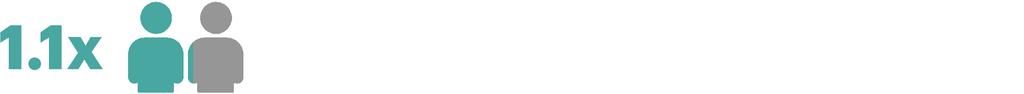

Black, non-Hispanic people were incarcerated in state prison past parole eligibility at a rate 1.1 times higher than White people, when accounting for prison population sizes in Mississippi.

Hispanic people were incarcerated in state prison past their parole eligibility at the same rate as White people, when accounting for prison population sizes in Mississippi.

Source: National Corrections Reporting Program, 2019 and CSG Justice Center estimates.

**Sex**

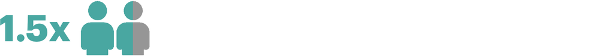

Men were incarcerated in state prison past parole eligibility at a rate 1.5 times higher than women, when accounting for prison population sizes in Mississippi.

Source: National Corrections Reporting Program, 2019 and CSG Justice Center estimates.

## Years in Prison Past Parole Eligibility

**Race and Ethnicity**

The chart below shows the average time spent in prison past parole eligibility by race and ethnicity for individuals still incarcerated. Black people spent more time in prison after becoming eligible for parole than White people. Hispanic people spent less time in prison after becoming eligible for parole than White people. Black people spent on average 8 months more past parole eligibility, and Hispanic people spent on average 6 months less past parole eligibility compared to White people.

[interactive chart not shown]

The chart below shows the average time spent in prison past parole eligibility by offense type and race and ethnicity for individuals still incarcerated. The largest disparity was observed among robbery offenses, where Hispanic people spent on average 3 years and 6 months more in prison compared to White people.

[interactive chart not shown]

**Sex**

The chart below shows the average time spent in prison past parole eligibility by sex for individuals still incarcerated. Women who were still incarcerated spent on average 1 year less past parole eligibility compared to men.

[interactive chart not shown]

The chart below shows the average time spent in prison past parole eligibility by offense type and sex for individuals still incarcerated. The largest disparity was observed among murder or nonnegligent manslaughter offenses, where men spent on average 3 years and 11 months more in prison compared to women.

[interactive chart not shown]

## Time Served

**Race and Ethnicity**

The chart below shows the average time served in prison by race and ethnicity for individuals released from prison. Black people and Hispanic people spent more time in prison than White people. Black people spent on average 9 months more in prison, and Hispanic people spent on average 1 year and 1 month more in prison compared to White people.

[interactive chart not shown]

The chart below shows the average time served in prison by offense type and race and ethnicity for individuals released from prison. The largest disparity was observed among negligent manslaughter offenses, where Hispanic people spent on average 3 years and 6 months more in prison compared to White people.

[interactive chart not shown]

**Sex**

The chart below shows the average time served in prison by sex among released individuals. Women released spent on average 11 months less in prison compared to men.

[interactive chart not shown]

The chart below shows the average time served in prison by offense type and sex for individuals released from prison. The largest disparity was observed among rape or sexual assault offenses, where men spent on average 3 years and 3 months more in prison compared to women.

[interactive chart not shown]

## Notes on Disparities

**Understanding Disparities in Parole Outcomes**

In examining disparities in parole release rates, this analysis uses the Relative Rate Index (RRI) as a metric to assess differences in incarceration past parole eligibility across race, ethnicity, and sex.

The RRI is calculated by dividing the rate for Black or Hispanic individuals by the rate for White individuals, with values above 1.0 indicating that a group experiences the outcome at a higher rate relative to White individuals and values below 1.0 indicating a lower rate. This allows for a comparative analysis of which groups are more likely to remain incarcerated past their parole eligibility.

**Metrics Displayed in Visualizations**

Our visualizations present three main metrics to highlight disparities across race, ethnicity, and sex:

- **RRI of Incarceration Past Parole Eligibility:** This metric quantifies the relative likelihood of remaining incarcerated past parole eligibility, comparing Black and Hispanic individuals to White individuals and men to women. An RRI above 1.0 signals a higher likelihood of delayed parole release, whereas an RRI below 1.0 indicates a lower likelihood. These disparities shed light on inequities in the parole release process.
- **Average Time Past Parole Eligibility:** For those individuals who remain incarcerated past their parole eligibility date, we show the average additional time spent in prison. This is broken down by race, ethnicity, and sex, highlighting the length of delay in parole release among different groups.
- **Average Total Time Served:** We also display the average total time served in prison by race, ethnicity, and sex, providing insight into sentencing and incarceration length disparities.

**Data Considerations**

Our analysis focuses on Black, Hispanic, and White categories to align with data limitations from the National Corrections Reporting Program (NCRP), which categorizes individuals as White, Black, Hispanic, or Other. The term “Hispanic” is used here to align with NCRP terminology.

Data collection and reporting practices vary significantly across states:

- **Race and Ethnicity Identification:** Some states collect race and ethnicity data based on intake officers’ assessments, while others allow individuals to self-identify. This may result in variability and influence RRI calculations.
- **Combined vs. Separate Categories:** Some states combine race and ethnicity into a single category, while others separate them. This inconsistency can impact the accuracy and comparability of data, sometimes leading to an underreporting of Hispanic individuals and mixed-race individuals or an overrepresentation of non-Hispanic White individuals.
- **Including ‘Other’ Category in Analysis:** In states where populations categorized as “Other race(s), non-Hispanic” are substantial, we include these groups in the analysis.

**Small Sample Sizes and Interpretation**

Interpret findings with small numbers cautiously, as they may introduce variability and yield less reliable estimates. We exclude individuals categorized as “Other race(s), non-Hispanic” when the sample size is too small to make meaningful comparisons. According to the NCRP, the “Other race(s)” category may include American Indian or Alaska Native, Asian, Native Hawaiian or Other Pacific Islander, and individuals identifying as more than one race. Small sample sizes can produce unreliable or potentially misleading results in disparities analysis.